# Relación espacial entre la población joven adulta (25–39 años) y el tamaño medio del hogar en el Gran Santiago

Joaquín Bravo Veas

2025-10-18

# 1. Introducción

El Gran Santiago, núcleo urbano más densamente poblado de Chile, constituye el eje económico, político y social del país. Según los primeros resultados del Censo 2024, la Región Metropolitana concentra 7 400 741 personas, equivalentes al 40 % de la población nacional (IDE Chile).

Este territorio metropolitano enfrenta múltiples retos urbanos: déficit habitacional, hacinamiento, segregación espacial, largas distancias de desplazamiento y desigualdad en el acceso a infraestructura y servicios. En particular, el déficit cuantitativo de viviendas se concentra en las comunas más densas del Gran Santiago, entre ellas Santiago, Maipú, Puente Alto y San Bernardo, que acumulan casi un cuarto del déficit regional (Déficit 0).

En paralelo, Chile está experimentando transformaciones demográficas profundas: envejecimiento poblacional, caída de la fecundidad y aumento de la cantidad de hogares unipersonales. El Censo 2024 reveló que un 14 % de la población tiene 65 años o más, y que el promedio de personas por hogar ha bajado a 2,8 individuos, evidenciando una tendencia hacia hogares más compactos (IDE Chile).

Frente a ese contexto, el presente estudio propone explorar dos dimensiones complementarias del perfil demográfico urbano en el Gran Santiago:

1. El **peso relativo de la población joven-adulta** (25 a 39 años) en cada zona censal: un segmento vital en términos laborales, reproductivos y de movilización social.
2. El **tamaño medio del hogar**: indicador clave para entender la densidad habitacional, las dinámicas residenciales y las presiones sobre la vivienda familiar.

Mediante análisis espacial y estadístico a escala de zonas censales, se busca revelar patrones territoriales y posibles correlaciones entre la concentración de población joven y la estructura de los hogares. La visualización en mapas temáticos y bivariados permitirá identificar zonas con superposición de ambos fenómenos, lo que puede aportar pistas valiosas para demanda inmobiliaria, politicas de vivienda, movilidad y planificación urbana más focalizadas para el Gran Santiago.

## 1.1 Objetivo general

El objetivo principal es representar la distribución espacial de la relación entre la población joven-adulta entre 25-39 años (grupo clave por su relevancia económica y reproductiva) junto con el tamaño medio de los hogares, indicador asociado a condiciones de vivienda, densidad habitacional y estructura familiar.

## 1.2 Objetivos especificos

Los objetivos específicos del presente estudio son:

- **Calcular el porcentaje de población etaria entre 25 y 39 años** en cada zona censal del Gran Santiago, como indicador del peso demográfico del grupo joven-adulto.
- **Estimar el tamaño medio del hogar** por zona censal, expresado como el promedio de personas por vivienda particular ocupada.
- **Representar de manera espacial y gráfica ambos indicadores** en mapas temácticos a nivel de zona censal y a través de gráficos de dispersión, para visualizar patrones de distribución intraurbana.
- **Analizar la relación bivariada** entre el porcentaje de población joven-adulta y el tamaño medio del hogar mediante técnicas de clasificación espacial (biscale), identificando áreas donde ambas condiciones se superponen, analizandolo a través de un mapa bivariado.
- **Interpretar los patrones espaciales resultantes**, destacando tendencias centro-periferia y su relevancia para la planificación urbana y habitacional en el Gran Santiago.

# 2. Desarrollo

## 2.1 Metodología

Para el desarrollo metodológico de este trabajo se utilizaron dos herramientas principales: pgAdmin y RStudio, con el objetivo de procesar, analizar y visualizar información proveniente del Censo 2017 y de la base geoespacial de la Región Metropolitana.

El análisis se centró en las zonas urbanas que conforman el Gran Santiago, comprendiendo la Provincia de Santiago junto a las comunas de San Bernardo y Puente Alto. Esta delimitación corresponde a la principal conurbación del país y permite capturar las dinámicas socioespaciales propias de la conurbación. La unidad de análisis fue la zona censal urbana, escala que posibilita distinguir diferencias intra-comunales y patrones locales de estructura poblacional.

La base de datos utilizada se almacenó y gestionó mediante PostgreSQL/PostGIS, aprovechando la interoperabilidad espacial para manipular los datos. Posteriormente, los resultados fueron procesados y representados en RStudio, utilizando diversas liberías y código para la creación de gráficos, mapas temáticos y bivariados.

### 2.1.1 Librerías

```r
library(DBI)
library(RPostgres)
library(sf)
library(dplyr)
library(ggplot2)
library(RColorBrewer)
library(cowplot)
library(biscale)
library(viridis)
library(ggrepel)
library(rlang)
library(scales)
library(grid)
```

### 2.1.2 Conexión a la base de datos PostgreSQL

Se realiza un proceso de conexión de R Studio con una base de datos local en PostgreSQL que contiene las tablas del Censo 2017 para la Región Metropolitana y capas con divisiones de zona censal y comunal.

```r
con <- dbConnect(
  Postgres(),
  dbname   = "censo_rm_2017",
  host     = "localhost",
  port     = 5432,
  user     = "postgres",
  password = "postgres"
)
```

El estudio se sustenta en información proveniente del Censo de Población y Vivienda 2017, gestionada en una base de datos relacional PostgreSQL con extensión espacial PostGIS. Los datos se organizaron en diversas tablas del esquema public, las cuales fueron vinculadas mediante identificadores comunes para construir una base integrada de análisis a nivel de zona censal urbana.

### 2.1.3 Tablas censales y variables utilizadas

Para calcular los indicadores deseados se utilizó la información contenida en las siguientes tablas censales y se consideraron las siguientes variables demográficas:

- **public.personas:** contiene registros individuales con variables demográficas. En este estudio se utilizaron principalmente:
  - **p09:** edad del individuo, expresada en años cumplidos, variable base para la estimación del porcentaje de población en el rango 25-39 años.
  - **p07:** tipo de residencia o condición de institucionalización, que permitió excluir del análisis a personas en establecimientos colectivos (códigos 17, 18, 19).
- **public.hogares:** define la unidad doméstica de convivencia. Se empleó el identificador hogar_ref_id para agrupar individuos pertenecientes al mismo hogar y calcular el tamaño medio del hogar.
- **public.viviendas:** enlaza los hogares con la unidad habitacional de referencia (vivienda_ref_id) y, a su vez, con la zona censal mediante el campo zonaloc_ref_id.
- **public.zonas:** contiene el código único de cada zona censal (geocodigo), utilizado como clave espacial para asociar la información demográfica con las geometrías.
- **public.comunas:** tabla auxiliar que permite identificar la comuna administrativa correspondiente a cada zona censal a través del campo codigo_comuna.

A nivel espacial se emplean:

- **dpa.zonas_censales_rm:** geometrías poligonales de las zonas censales de la Región Metropolitana.
- **dpa.comunas_rm_shp:** límites comunales.

Las capas espaciales se leen a través del siguiente bloque de código:

```r
zonas_censales_rm <- st_read(con, query = "SELECT * FROM dpa.zonas_censales_rm;")
comunas_rm_shp    <- st_read(con, query = "SELECT * FROM dpa.comunas_rm_shp;")

names(zonas_censales_rm) <- tolower(names(zonas_censales_rm))
names(comunas_rm_shp)    <- tolower(names(comunas_rm_shp))
```

### 2.1.4 Ajuste de zona de estudio y filtro de zonas urbanas

Con el fin de que los productos posteriores se enfoquen en el Gran Santiago, se aplica un filtro a la capa de comunas para seleccionar solo la Provincia de Santiago además de la comuna de San Bernardo y Puente Alto.

```r
norm <- function(x){ x <- iconv(x, to="ASCII//TRANSLIT"); tolower(trimws(x)) }

if (!"nom_comuna" %in% names(comunas_rm_shp)) {
  alt <- intersect(c("nombre","comuna","name"), names(comunas_rm_shp))
  comunas_rm_shp <- rename(comunas_rm_shp, nom_comuna = !!alt[1])
}

prov_col <- intersect(c("nom_provin","nom_provincia","provincia"), names(comunas_rm_shp))
comunas_rm_shp <- comunas_rm_shp |>
  mutate(nom_std  = norm(nom_comuna),
         prov_std = norm(.data[[prov_col[1]]]))

extra_comunas <- norm(c("San Bernardo","Puente Alto"))
sf_comunas <- comunas_rm_shp |>
  filter(prov_std == "santiago" | nom_std %in% extra_comunas)

if (!st_crs(zonas_censales_rm) == st_crs(sf_comunas)) {
  sf_comunas <- st_transform(sf_comunas, st_crs(zonas_censales_rm))
}
```

Luego se realiza el recorte para considerar solo las áreas urbanas del Gran Santiago ajustado anteriormente, esto con el fin de focalizar los mapas finales y no tener sectores sin información en el mapa, habiendo aplicado el recorte se aplica la división de zona censal dentro de la zona urbana del Gran Santiago.

```r
urb_cols <- intersect(c("urbano","es_urbano","urban","zona_urbana","urb"), names(zonas_censales_rm))
if (length(urb_cols)) {
  zonas_censales_rm <- zonas_censales_rm |>
    mutate(.urb_ = !!sym(urb_cols[1])) |>
    filter(.urb_ %in% c(1, TRUE) | norm(as.character(.urb_)) %in% c("u","urbano","urban"))
}

sf_zonas_tgt <- st_join(zonas_censales_rm, sf_comunas[,0], join = st_intersects, left = FALSE)

u_zonas <- st_union(sf_zonas_tgt)
bb <- st_bbox(st_buffer(u_zonas, dist = 2000))
xlim_zoom <- c(bb["xmin"], bb["xmax"])
ylim_zoom <- c(bb["ymin"], bb["ymax"])

comunas_clip <- suppressWarnings(st_intersection(sf_comunas, st_as_sf(u_zonas))) |>
  group_by(nom_comuna) |>
  summarise(.groups="drop")

bordes_comunas <- st_cast(st_boundary(comunas_clip), "MULTILINESTRING")
```

### 2.1.5 Definición y cálculo de indicadores

Para obtener el análisis bivariado se calcularon los 2 indicadores anteriormente mencionados a través de las siguientes formulas y condiciones:

- **Porcentaje de población 25-39 años (pct_25_39)**

Corresponde al porcentaje de personas cuyas edades están entre 25 y 39 años dentro de cada zona censal.

$$pct_{25-39} = \frac{N_{25-39}}{N_{total}} \times 100$$

Este grupo etario es clave por su participación activa en el mercado laboral, su potencial reproductivo y su influencia en las dinámicas urbanas.

- **Tamaño medio del hogar (tam_med_hogar)**

Corresponde al promedio de personas por hogar en cada zona censal, estimado a partir del número total de personas censadas y el número de hogares distintos registrados.

$$tam_{med\_hogar} = \frac{N_{personas}}{N_{hogares}}$$

Este indicador se asocia a condiciones habitacionales, densidad poblacional y características socioeconómicas del territorio.

Ambos indicadores fueron filtrados para zonas urbanas y posteriormente representados en mapas temáticos y bivariados, lo que permitió identificar espacialmente patrones de concentración de población joven y variaciones en el tamaño promedio de los hogares dentro del Gran Santiago.

Estos fueron calculados a través de la siguiente consulta en lenguaje SQL en R Studio:

```r
sql_ind_rm <- "
WITH base AS (
  SELECT
    z.geocodigo::text AS geocodigo,
    c.nom_comuna,
    p.p09, p.p07, h.hogar_ref_id
  FROM public.personas p
  JOIN public.hogares h  ON p.hogar_ref_id    = h.hogar_ref_id
  JOIN public.viviendas v ON h.vivienda_ref_id = v.vivienda_ref_id
  JOIN public.zonas z     ON v.zonaloc_ref_id  = z.zonaloc_ref_id
  JOIN public.comunas c   ON z.codigo_comuna   = c.codigo_comuna
),
particulares AS (
  SELECT * FROM base
  WHERE p07 NOT IN (17,18,19)
    AND p09 NOT IN (131,132)
),
agg AS (
  SELECT
    geocodigo,
    MAX(nom_comuna) AS nom_comuna,
    ROUND(COUNT(*) FILTER (WHERE p09 BETWEEN 25 AND 39) * 100.0 / NULLIF(COUNT(*),0), 2) AS pct_25_39,
    ROUND(COUNT(*)::numeric / NULLIF(COUNT(DISTINCT hogar_ref_id),0), 2) AS tam_med_hogar
  FROM particulares
  GROUP BY geocodigo
)
SELECT * FROM agg;
"

tbl_ind <- dbGetQuery(con, sql_ind_rm) |> mutate(geocodigo = as.character(geocodigo))
sf_ind <- sf_zonas_tgt |> mutate(geocodigo = as.character(geocodigo)) |> left_join(tbl_ind, by="geocodigo")
```

### 2.1.6 Definición del tema y paletas

Finalmente en esta parte del código se define la estética visual de los mapas y el gráfico bivariado, definiendo los colores, márgenes, tipografía, posición de la leyenda, entre otros.

```r
pal_blues <- c("#f7fbff","#deebf7","#c6dbef","#9ecae1","#6baed6","#3182bd","#08519c")

theme_joaquín <- function() {
  theme_minimal(base_size = 12) +
    theme(
      panel.grid.major = element_line(color = "grey85", linewidth = 0.3),
      panel.grid.minor = element_blank(),
      axis.text = element_text(color = "grey30"),
      axis.title = element_blank(),
      axis.ticks = element_blank(),
      plot.title = element_text(face = "bold", size = 14),
      plot.subtitle = element_text(color = "grey30", size = 11),
      plot.caption = element_text(size = 8, color = "grey40"),
      legend.position = "right",
      legend.justification = "center",
      legend.title = element_text(face = "bold"),
      legend.key.height = unit(14, "pt"),
      legend.key.width  = unit(10, "pt"),
      plot.margin = margin(10, 40, 10, 10)
    )
}
```

# 3. Resultados y Análisis

## 3.1 Histogramas de indicadores

De manera preliminar se realizan histogramas para cada indicador con el fin de poder visualizar los datos enfocandónos solo en la distribución de cada indicador en su respectiva unidad de medida sin considerar la variable espacial. Los histogramas presentados permiten observar la distribución de las dos variables principales analizadas a nivel de zona censal urbana del Gran Santiago: el porcentaje de población joven-adulta (25-39 años) y el tamaño medio del hogar.

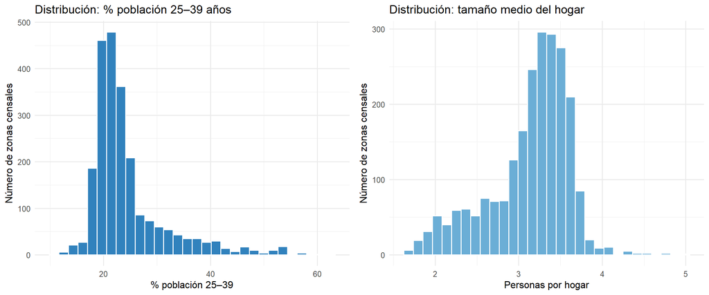

```r
df_plot <- sf_ind |>
  sf::st_drop_geometry() |>
  dplyr::select(pct_25_39, tam_med_hogar) |>
  dplyr::filter(is.finite(pct_25_39), is.finite(tam_med_hogar))

p_hist_25_39 <- ggplot(df_plot, aes(x = pct_25_39)) +
  geom_histogram(bins = 30, fill = "#3182bd", color = "white") +
  labs(
    title = "Distribución: % población 25–39 años",
    x = "% población 25–39",
    y = "Número de zonas censales"
  ) +
  theme_minimal(base_size = 12)

p_hist_hogar <- ggplot(df_plot, aes(x = tam_med_hogar)) +
  geom_histogram(bins = 30, fill = "#6baed6", color = "white") +
  labs(
    title = "Distribución: tamaño medio del hogar",
    x = "Personas por hogar",
    y = "Número de zonas censales"
  ) +
  theme_minimal(base_size = 12)

cowplot::plot_grid(p_hist_25_39, p_hist_hogar, ncol = 2, rel_widths = c(1, 1))
```

#### 3.1.1 Distribución del porcentaje de población 25–39 años

La distribución presenta una asimetría positiva, es decir que la mayoría de las zonas censales contienen bajos valores de porcentaje de población joven, concentrándose la mayoría de las zonas censales entre el 15 % y 25 % de población en este grupo etario, con un pico modal cercano al 20 %. Esto sugiere que en la mayor parte del Gran Santiago la proporción de población joven-adulta es relativamente moderada, mientras que las zonas con porcentajes superiores al 35-40 % son escasas y corresponden probablemente a sectores con fuerte presencia de adultos jóvenes, como áreas de renovación urbana, zonas centrales o comunas con alta migración laboral reciente (p. ej. Santiago Centro, Ñuñoa o Independencia).

#### 3.1.2 Distribución del tamaño medio del hogar

El tamaño medio del hogar muestra una distribución levemente asimétrica hacia la izquierda, concentrando la mayor parte de las zonas censales entre 2,5 y 3,5 personas por hogar, con un valor modal cercano a 3 personas. Esto refleja una tendencia general hacia hogares de tamaño reducido, coherente con las dinámicas urbanas actuales del Gran Santiago: aumento de hogares unipersonales, parejas sin hijos y fragmentación familiar.

Sin embargo, la presencia de un número menor de zonas con promedios superiores a 4 personas por hogar sugiere la persistencia de núcleos familiares más extensos en algunas zonas censales del Gran Santiago.

Habiendo realizado este análisis preliminar seguimos con la visualización espacial de cada uno de los indicadores para poder profundizar el análisis dentro de las zonas urbanas del Gran Santiago.

## 3.2 Cartografías

#### 3.2.1 Porcentaje de población entre 25-39 años por zona censal, Gran Santiago

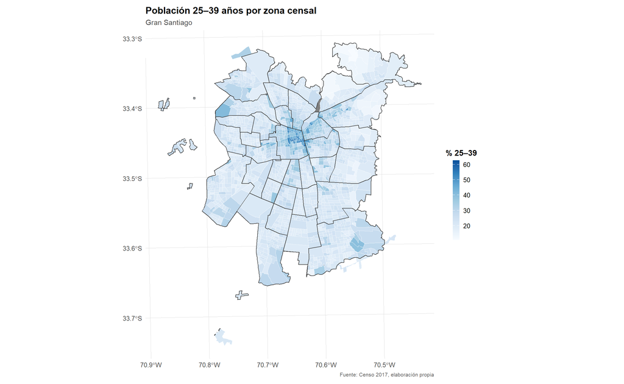

```r
ggplot(sf_ind) +
  geom_sf(aes(fill = pct_25_39), color = alpha("white", 0.6), linewidth = 0.15) +
  geom_sf(data = bordes_comunas, fill = NA, color = "grey25", linewidth = 0.45) +
  coord_sf(xlim = xlim_zoom, ylim = ylim_zoom, expand = FALSE, label_graticule = "SW", label_axes = "SW") +
  scale_fill_gradientn(
    colors = pal_blues,
    name = "% 25–39",
    breaks = pretty_breaks(6),
    labels = label_number(accuracy = 1, decimal.mark = ",")
  ) +
  guides(fill = guide_colorbar(barheight = unit(120, "pt"), title.position = "top", title.hjust = 0.5)) +
  labs(
    title = "Población 25–39 años por zona censal",
    subtitle = "Gran Santiago",
    caption = "Fuente: Censo 2017, elaboración propia"
  ) +
  theme_joaquín()
```

El mapa de distribución por zona censal muestra una clara concentración de la población joven-adulta (25–39 años) en el área central del Gran Santiago, especialmente en torno a la comuna de Santiago, donde destacan las zonas censales del sector nororiente como las de Santa Isabel, Parque Almagro y Bellas Artes. Estas áreas presentan los valores más altos del indicador, superando el 40 % e incluso alcanzando rangos cercanos al 60 %, lo que evidencia una fuerte presencia de población joven-adulta asociada a procesos de renovación urbana y densificación residencial.

En continuidad espacial, las comunas de Providencia, Ñuñoa, San Miguel e Independencia también exhiben valores relativamente elevados, aunque en menor magnitud que el núcleo central. Estas zonas corresponden a sectores consolidados del área metropolitana, con buena accesibilidad al transporte público, oferta de servicios y equipamientos urbanos, lo que atrae a población joven-adulta en edad laboral.

Hacia la periferia, la proporción de población joven-adulta disminuye de manera notoria, predominando zonas censales con valores bajo el 25 %. Sin embargo, se observan algunos núcleos atípicos de mayor concentración en sectores específicos de Puente Alto y Renca, donde probablemente inciden factores como la expansión de proyectos habitacionales recientes o la llegada de nuevos hogares jóvenes en búsqueda de viviendas más asequibles.

En conjunto, la distribución espacial del indicador revela un patrón centro-periferia inverso, donde la población joven se concentra en los sectores centrales y pericentrales, mientras que la periferia metropolitana presenta una estructura demográfica más envejecida o familiarmente consolidada. Este comportamiento es coherente con las transformaciones residenciales observadas en las últimas décadas en el Gran Santiago, caracterizadas por la reurbanización de los barrios centrales y la fragmentación socioespacial de la juventud urbana.

#### 3.2.2 Tamaño medio de hogar por zona censal, Gran Santiago

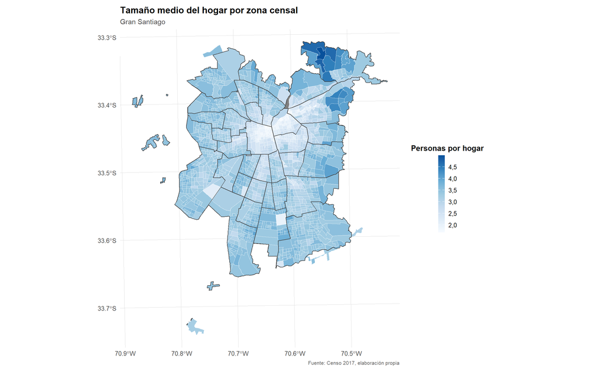

```r
ggplot(sf_ind) +
  geom_sf(aes(fill = tam_med_hogar), color = alpha("white", 0.6), linewidth = 0.15) +
  geom_sf(data = bordes_comunas, fill = NA, color = "grey25", linewidth = 0.45) +
  coord_sf(xlim = xlim_zoom, ylim = ylim_zoom, expand = FALSE, label_graticule = "SW", label_axes = "SW") +
  scale_fill_gradientn(
    colors = pal_blues,
    name = "Personas por hogar",
    breaks = pretty_breaks(6),
    labels = label_number(accuracy = 0.1, decimal.mark = ",")
  ) +
  guides(fill = guide_colorbar(barheight = unit(120, "pt"), title.position = "top", title.hjust = 0.5)) +
  labs(
    title = "Tamaño medio del hogar por zona censal",
    subtitle = "Gran Santiago",
    caption = "Fuente: Censo 2017, elaboración propia"
  ) +
  theme_joaquín()
```

El mapa de distribución del tamaño medio del hogar evidencia un patrón espacial heterogéneo dentro del Gran Santiago, donde se observan diferencias significativas entre las comunas del oriente, el centro y las periferias de la ciudad.

Las zonas con los valores más altos de personas por hogar (superiores a 4,3 personas en promedio) se concentran en el sector oriente, destacando las zonas censales del norte de Las Condes y el sur y oriente de Lo Barnechea, particularmente en áreas como El Arrayán, La Dehesa y Los Trapenses, que combinan una alta proporción de viviendas familiares con presencia de hogares extensos.

En un rango ligeramente menor, también se identifican zonas con promedios elevados en La Reina y Peñalolén, donde aún predominan viviendas unifamiliares y hogares nucleares con hijos, reflejando dinámicas demográficas más tradicionales.

En contraste, las zonas censales con menor tamaño medio del hogar (entre 2 y 3 personas) se concentran en el área central y pericentral del Gran Santiago, especialmente en las comunas de Santiago, Providencia, Ñuñoa, San Miguel e Independencia. Estos valores más bajos se relacionan con procesos de densificación vertical y renovación urbana, caracterizados por el aumento de viviendas en altura y la proliferación de hogares unipersonales o de parejas jóvenes sin hijos, propios de zonas urbanas consolidadas con mayor acceso a servicios y transporte.

Hacia las periferias en general, en comunas como Maipú, Cerrillos y San Bernardo, los valores son intermedios (entre 3 y 3,5 personas por hogar), representando áreas de expansión urbana reciente con mezcla de familias jóvenes, nuevos conjuntos habitacionales y hogares de tamaño medio.

En conjunto, el mapa revela un gradiente centro-periferia con matices oriente-poniente, donde los hogares pequeños dominan en el centro urbano y las zonas verticalizadas, mientras que los hogares de mayor tamaño se concentran hacia el oriente y en algunos sectores periféricos. Este patrón refleja las diferencias socioeconómicas y morfológicas del Gran Santiago, donde el sector oriente concentra hogares familiares de mayor tamaño vinculados a viviendas amplias, y el centro urbano presenta hogares más reducidos y atomizados, en correspondencia con los procesos contemporáneos de transformación residencial y segmentación del espacio urbano.

Habiendo realizado el análisis para cada indicador por separado a continuación analizaremos la relación conjunta a través de la distribución de los datos gráficamente en cuartiles y luego espacialmente en el mapa bivariado.

#### 3.2.3 Gráfico de dispersión entre porcentaje de población 25-39 y tamaño medio del hogar por zona censal, Gran Santiago

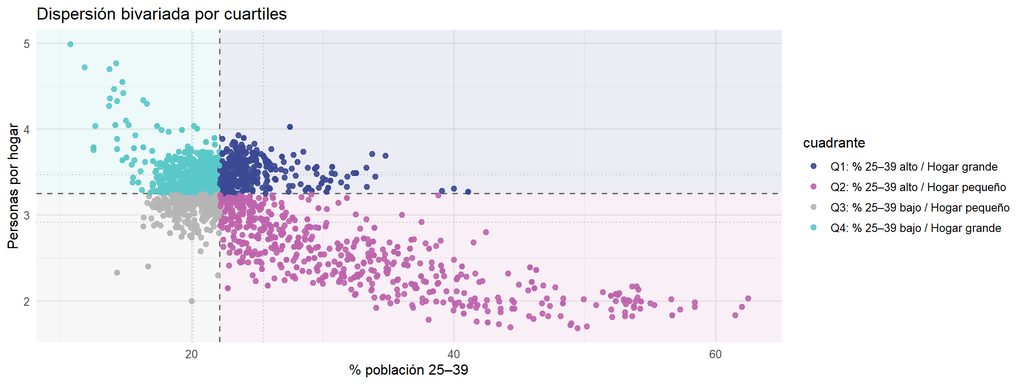

```r
df_plot <- sf_ind |>
  sf::st_drop_geometry() |>
  dplyr::select(pct_25_39, tam_med_hogar) |>
  dplyr::filter(is.finite(pct_25_39), is.finite(tam_med_hogar))

qx <- quantile(df_plot$pct_25_39,     probs = c(.25,.5,.75), na.rm = TRUE)
qy <- quantile(df_plot$tam_med_hogar, probs = c(.25,.5,.75), na.rm = TRUE)

df_bi <- df_plot |>
  dplyr::mutate(
    cuadrante = dplyr::case_when(
      pct_25_39 >= qx[2] & tam_med_hogar >= qy[2] ~ "Q1: % 25–39 alto / Hogar grande",
      pct_25_39 >= qx[2] & tam_med_hogar <  qy[2] ~ "Q2: % 25–39 alto / Hogar pequeño",
      pct_25_39 <  qx[2] & tam_med_hogar <  qy[2] ~ "Q3: % 25–39 bajo / Hogar pequeño",
      TRUE                                        ~ "Q4: % 25–39 bajo / Hogar grande"
    )
  )

col_bi <- c(
  "Q1: % 25–39 alto / Hogar grande"   = "#3b4994",
  "Q2: % 25–39 alto / Hogar pequeño"  = "#be64ac",
  "Q3: % 25–39 bajo / Hogar pequeño"  = "#b5b5b5",
  "Q4: % 25–39 bajo / Hogar grande"   = "#5ac8c8"
)

ggplot(df_bi, aes(x = pct_25_39, y = tam_med_hogar)) +
  annotate("rect", xmin=-Inf, xmax=qx[2], ymin=-Inf, ymax=qy[2], fill="#b5b5b5", alpha=.10) +
  annotate("rect", xmin=qx[2], xmax= Inf, ymin=-Inf, ymax=qy[2], fill="#be64ac", alpha=.10) +
  annotate("rect", xmin=-Inf, xmax=qx[2], ymin=qy[2], ymax= Inf, fill="#5ac8c8", alpha=.10) +
  annotate("rect", xmin=qx[2], xmax= Inf, ymin=qy[2], ymax= Inf, fill="#3b4994", alpha=.10) +
  geom_vline(xintercept = qx[2], linetype = 2, color = "grey40") +
  geom_hline(yintercept = qy[2], linetype = 2, color = "grey40") +
  geom_vline(xintercept = c(qx[1], qx[3]), linetype = 3, color = "grey70", linewidth = .4) +
  geom_hline(yintercept = c(qy[1], qy[3]), linetype = 3, color = "grey70", linewidth = .4) +
  geom_point(aes(color = cuadrante), alpha = .9, size = 2) +
  scale_color_manual(values = col_bi, name = "cuadrante") +
  labs(title = "Dispersión bivariada por cuartiles",
       x = "% población 25–39",
       y = "Personas por hogar") +
  theme_minimal(base_size = 12)
```

El gráfico de dispersión bivariada muestra la relación entre el porcentaje de población joven-adulta (25-39 años) y el tamaño medio del hogar por zona censal en el Gran Santiago. La clasificación en cuartiles permite identificar cuatro cuadrantes que combinan diferentes niveles de ambos indicadores, revelando patrones espaciales y demográficos distintivos dentro del área metropolitana.

En términos generales, se observa una relación inversa entre ambas variables: a medida que aumenta el porcentaje de población joven (eje X), el tamaño medio del hogar (eje Y) tiende a disminuir. Este comportamiento indica que las zonas donde predominan los adultos jóvenes suelen presentar hogares más pequeños, mientras que los sectores con menor presencia de este grupo etario tienden a tener hogares más extensos.

Los cuadrantes permiten distinguir distintos comportamientos:

- El **Q2** concentra la mayor cantidad de zonas, caracterizadas por una alta proporción de población joven y hogares pequeños, lo que sugiere una predominancia de estructuras domésticas reducidas.
- En contraste, el **Q4** agrupa zonas con baja presencia de población joven y hogares de mayor tamaño, mientras que el **Q1 y Q3** representan casos menos frecuentes con combinaciones intermedias.

En conjunto, el gráfico evidencia una correlación negativa moderada entre ambas variables, donde las áreas con más población joven tienden a presentar hogares de menor tamaño promedio.

Ahora habiendo visto la dispersión de los datos de la relación bivariada la vamos a análizar de manera espacial a través del mapa del Gran Santiago.

#### 3.2.4 Relación entre porcentaje de población 25-39 y tamaño medio del hogar por zona censal, Gran Santiago

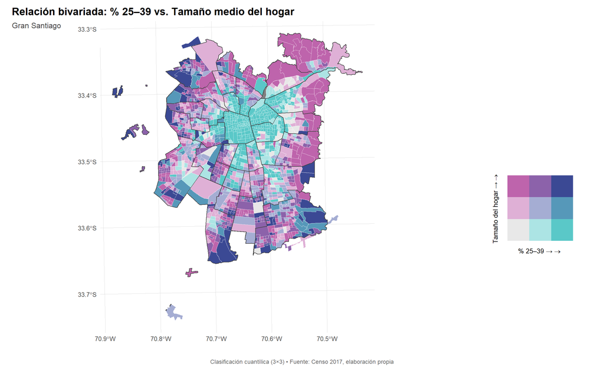

```r
sf_bi <- biscale::bi_class(
  sf_ind,
  x = pct_25_39,
  y = tam_med_hogar,
  dim = 3,
  style = "quantile"
)

map_bi <- ggplot(sf_bi) +
  geom_sf(aes(fill = bi_class), color = scales::alpha("white", 0.6), linewidth = 0.15, show.legend = FALSE) +
  geom_sf(data = bordes_comunas, fill = NA, color = "grey25", linewidth = 0.45) +
  biscale::bi_scale_fill(pal = "DkBlue", dim = 3) +
  coord_sf(xlim = xlim_zoom, ylim = ylim_zoom, expand = FALSE,
           label_graticule = "SW", label_axes = "SW") +
  theme_joaquín()

legend_core <- biscale::bi_legend(
  pal  = "DkBlue",
  dim  = 3,
  xlab = "% 25–39 \u2192",
  ylab = "Tamaño del hogar \u2192",
  size = 10
) +
  theme_minimal(base_size = 10) +
  theme(
    panel.grid   = element_blank(),
    axis.text    = element_blank(),
    axis.ticks   = element_blank(),
    axis.title.x = element_text(margin = margin(t = 6)),
    axis.title.y = element_text(margin = margin(r = 6)),
    plot.margin  = margin(8, 8, 8, 8)
  )

p_final <- cowplot::ggdraw() +
  cowplot::draw_plot(map_bi,     x = 0.00, y = 0.06, width = 0.78, height = 0.90) +
  cowplot::draw_plot(legend_core,x = 0.80, y = 0.30, width = 0.17, height = 0.25) +
  cowplot::draw_label("Relación bivariada: % 25–39 vs. Tamaño medio del hogar",
                      x = 0.02, y = 0.98, hjust = 0, vjust = 1, size = 16, fontface = "bold") +
  cowplot::draw_label("Gran Santiago",
                      x = 0.02, y = 0.94, hjust = 0, vjust = 1, size = 12, color = "grey30") +
  cowplot::draw_label("Clasificación cuantílica (3×3) • Fuente: Censo 2017, elaboración propia",
                      x = 0.50, y = 0.02, hjust = 0.5, vjust = 0, size = 9, color = "grey40")

p_final
```

El mapa bivariado combina las dos variables mencionadas anteriormente, siendo estas el porcentaje de población de 25 a 39 años y el tamaño medio del hogar mediante una clasificación cuantílica (3×3) que permite visualizar la distribución espacial conjunta de ambos indicadores.

Desde una lectura espacial, el patrón muestra una distribución claramente diferenciada entre el centro y la periferia de la conurbación.

Las zonas centrales y pericentrales del Gran Santiago, principalmente en las comunas de Santiago, Providencia, Ñuñoa, Independencia y San Miguel, presentan tonalidades calipso que reflejan una alta concentración de población joven (25-39 años) combinada con hogares pequeños. Este patrón coincide con áreas densificadas y verticalizadas, donde predominan viviendas de menor tamaño y estructuras domésticas reducidas.

En contraste, hacia la periferia, en comunas como Lo Barnechea, Las Condes, Peñalolén, La Reina, Huechuraba, Puente Alto, entre otras, se observan tonalidades de color morado, asociadas a hogares de mayor tamaño y una menor proporción de población joven, propias de sectores residenciales consolidados o de familias numerosas.

El mapa evidencia, por tanto, una relación espacialmente inversa entre ambas variables: mientras la población joven se concentra en sectores centrales con hogares pequeños, los hogares más extensos predominan en las áreas periféricas.

Este patrón sugiere un proceso de segmentación socioespacial, donde el ciclo de vida familiar, la oferta habitacional y las condiciones socioeconómicas influyen en la distribución territorial de los distintos grupos etarios dentro del área metropolitana.

# 4. Conclusión

El análisis conjunto de la población de 25 a 39 años y el tamaño medio del hogar en el Gran Santiago permitió evidenciar patrones demográficos y espaciales que reflejan la estructura socioresidencial de la conurbación.

En primer lugar, los histogramas mostraron que ambos indicadores presentan distribuciones asimétricas: la proporción de población joven-adulta se concentra mayoritariamente en rangos intermedios (entre 15% y 25%), mientras que el tamaño medio del hogar se mantiene entre 3 y 3,5 personas.

El análisis bivariado reveló una tendencia inversa entre ambas variables, donde las zonas con mayor porcentaje de población joven presentan hogares de menor tamaño promedio. Esta relación se confirmó espacialmente en el mapa bivariado, el cual mostró una clara diferenciación centro-periferia: el centro metropolitano (Santiago, Providencia, Ñuñoa, San Miguel) agrupa hogares pequeños con alta presencia de adultos jóvenes, mientras que las comunas periféricas (Puente Alto, Lo Barnechea, Peñalolén, Maipú) concentran hogares más extensos y menor proporción de este grupo etario.

En conjunto, los resultados reflejan procesos de fragmentación y diferenciación socioespacial, donde el ciclo de vida familiar, las condiciones del mercado habitacional y la estructura socioeconómica condicionan la distribución territorial de la población joven. El Gran Santiago evidencia así una organización espacial marcada por la centralidad juvenil y la periferia familiar, coherente con las dinámicas urbanas contemporáneas de las grandes ciudades latinoamericanas.

# 5. Bibliografía

- Instituto Nacional de Estadísticas. (2025, 27 de marzo). *Primeros resultados del Censo 2024: 18 480 432 personas fueron censadas en Chile* [Comunicado de prensa]. Gobierno de Chile. https://www.ine.gob.cl/sala-de-prensa/prensa/general/noticia/primeros-resultados-del-censo-2024-18 480 432-personas-fueron-censadas-en-chile (Consultado el 18 oct 2025).
- Centro de Políticas Públicas UC & Corporación Déficit Cero. (2022). *Ideas clave del Gran Santiago – Déficit Cero* [Informe]. [https://deficitcero.cl/uploads/estudios/GRAN_SANTIAGO.pdf](https://deficitcero.cl/uploads/estudios/GRAN_SANTIAGO.pdf?utm_source=chatgpt.com) (Consultado el 18 oct 2025).
- Centro de Despliegue Transporte Informa. (2017, noviembre). *Distribución comunas Gran Santiago, noviembre 2017* [PDF]. Transporte Informa. [https://www.transporteinforma.cl/wp-content//uploads/2019/02/Distribucio%CC%81n-Comunas-Gran-Santiago-noviembre-2017.pdf](https://www.transporteinforma.cl/wp-content//uploads/2019/02/Distribucio%CC%81n-Comunas-Gran-Santiago-noviembre-2017.pdf?utm_source=chatgpt.com)
- Instituto Nacional de Estadísticas (INE). (s. f.). *Censo de población y vivienda* [Página web]. Recuperado de [https://www.ine.gob.cl/estadisticas/sociales/censos-de-poblacion-y-vivienda](https://www.ine.gob.cl/estadisticas/sociales/censos-de-poblacion-y-vivienda?utm_source=chatgpt.com)